# Chess Games Exploration

Let's plot bar charts with the means of rating difference and number of turns that may be clearer.

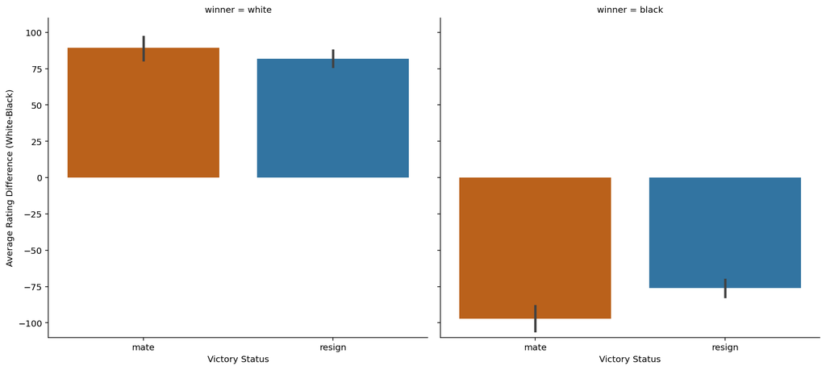

```python
# plotting victory status against average rating difference for each winner
g = sb.FacetGrid(data=games, col='winner', col_order=['white','black'], height=6, aspect=1.1)
g.map(sb.barplot,'victory_status' , 'rating_diff_wb',order=['mate','resign']
      , palette=[sb.color_palette('colorblind')[3],sb.color_palette()[0]]);
plt.ylim(-110,110)
g.axes[0,0].set_xlabel('Victory Status');
g.axes[0,0].set_ylabel('Average Rating Difference (White-Black)');
g.axes[0,1].set_xlabel('Victory Status');
```

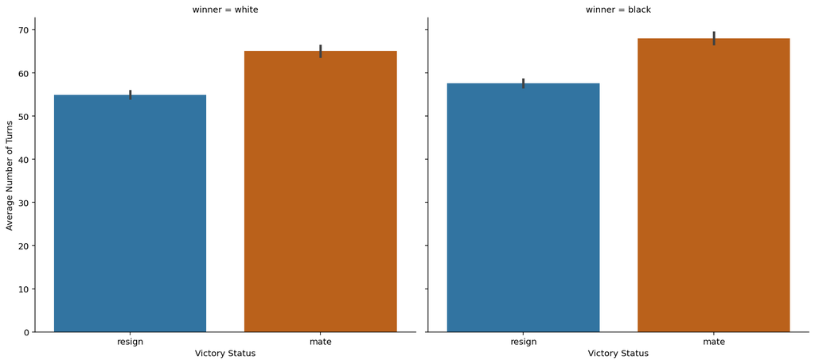

```python
# plotting victory status against average number of turns for each winner
g = sb.FacetGrid(data=games, col='winner', col_order=['white','black'], height=6, aspect=1.1)
g.map(sb.barplot,'victory_status' , 'turns',order=['resign','mate']
      , palette=[sb.color_palette()[0],sb.color_palette('colorblind')[3]]);
g.axes[0,0].set_xlabel('Victory Status');
g.axes[0,0].set_ylabel('Average Number of Turns');
g.axes[0,1].set_xlabel('Victory Status');
```

Games won by checkmate need, on average, higher number of turns and higher rating difference between players in favor of the winner compared to games won by resigning regardless of the winner, white or black.

I want to include another variable which is game rating, but first let's see its variation with rating difference and number of turns.

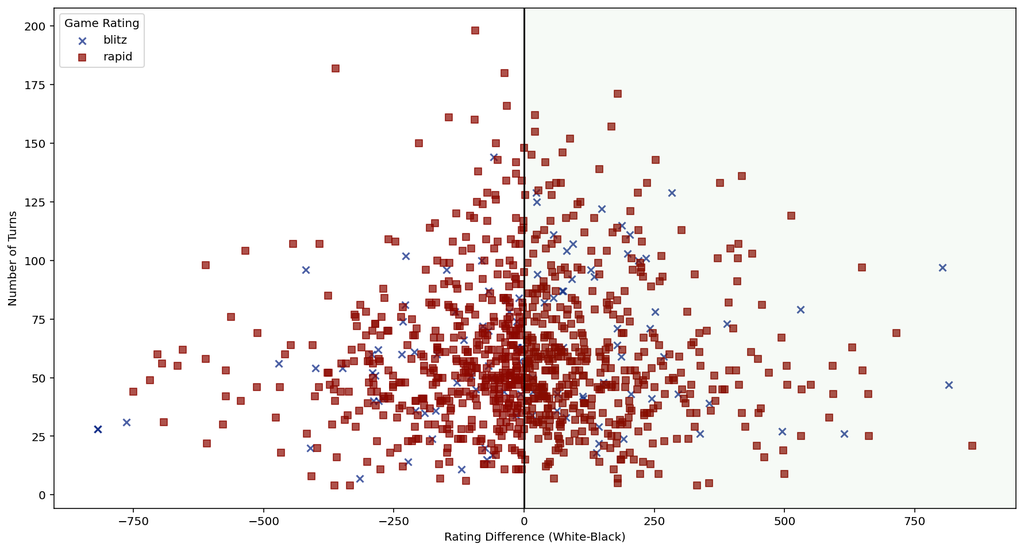

```python
# scatter plot of rating difference versus number of turns for each game rating
gameRating_markers= [['blitz', 'x', sb.color_palette('dark')[0]],
                ['rapid', 's', sb.color_palette('dark')[3]]]

plt.figure(figsize=(15,8))
for gameRating, marker, color in gameRating_markers:
    ax=sb.regplot(data = games_sample.loc[games_sample['game_rating']==gameRating], x = 'rating_diff_wb', y = 'turns',
               fit_reg = False, marker = marker, scatter_kws={'alpha':0.7,'color': color});

plt.legend(title='Game Rating', labels=['blitz','rapid']);
plt.xlim(ax.get_xlim())
plt.axvspan(0,ax.get_xlim()[1], facecolor='g', alpha=0.035)
plt.axvline(0, color='k')
plt.xlabel('Rating Difference (White-Black)')
plt.ylabel('Number of Turns');
```

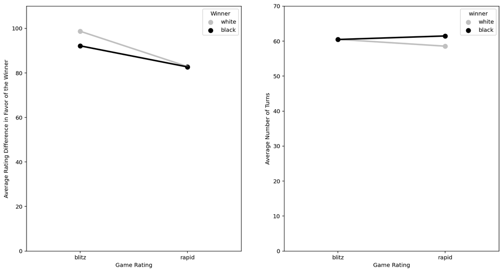

```python
# plotting game rating against rating difference and against number of turns for each winner
plt.figure(figsize=(15,8))

# first plot
# to make the comparison clearer between white an black I will take the absolute of mean rating difference

plt.subplot(1,2,1)
white_data=games.query('winner=="white"').groupby('game_rating')['rating_diff_wb'].mean().abs()
sb.pointplot(x=white_data.index, y=white_data.values, hue=['white']*len(white_data.values),
                 palette=['silver']*len(white_data.values))

black_data=games.query('winner=="black"').groupby('game_rating')['rating_diff_wb'].mean().abs()
sb.pointplot(x=black_data.index, y=black_data.values, hue=['black']*len(black_data.values),
             palette=['black']*len(black_data.values))
plt.xlabel('Game Rating')
plt.ylabel('Average Rating Difference in Favor of the Winner')
plt.ylim(0,110);
plt.legend(title='Winner');



# second plot

plt.subplot(1,2,2)
sb.pointplot(data=games, x='game_rating', y='turns', hue='winner', order=['blitz','rapid'], hue_order=['white','black'],
            palette=['silver', 'black'], ci=False)
plt.ylim(0,70);
plt.xlabel('Game Rating')
plt.ylabel('Average Number of Turns');
```

These plots prove what I learned in the previous scatter plot with some additional findings;

- blitz rating games won by more skilled players as white compared to players as black,
- players as black tend to take more number of turns to win a rapid rating game.

Let's add victory status variable to each of the previous two plots.

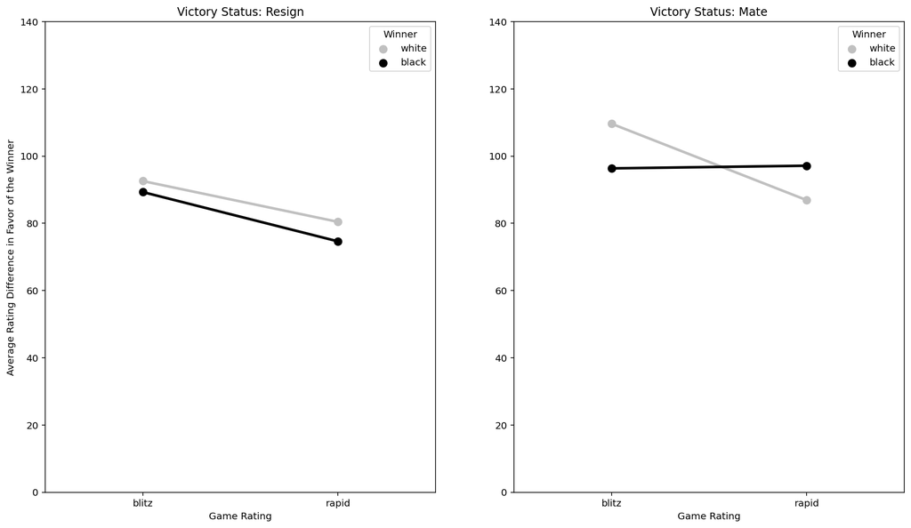

```python
# plotting game rating against rating difference for each winner  and each victory status

# first plot
plt.figure(figsize=(16,9))
plt.subplot(1,2,1)
white_data=games.query('winner=="white" & victory_status=="resign"').groupby('game_rating')['rating_diff_wb'].mean().abs()
ax2=sb.pointplot(x=white_data.index, y=white_data.values, hue=['white']*len(white_data.values),
                 palette=['silver']*len(white_data.values))

black_data=games.query('winner=="black" & victory_status=="resign"').groupby('game_rating')['rating_diff_wb'].mean().abs()
ax1= sb.pointplot(x=black_data.index, y=black_data.values, hue=['black']*len(black_data.values),
                  palette=['black']*len(black_data.values))
plt.ylim(0,140);
plt.xlabel('Game Rating')
plt.ylabel('Average Rating Difference in Favor of the Winner')
plt.title('Victory Status: Resign');
plt.legend(title='Winner');


# second plot
plt.subplot(1,2,2)
white_data=games.query('winner=="white" & victory_status=="mate"').groupby('game_rating')['rating_diff_wb'].mean().abs()
ax2=sb.pointplot(x=white_data.index, y=white_data.values, hue=['white']*len(white_data.values),
                 palette=['silver']*len(white_data.values))

black_data=games.query('winner=="black" & victory_status=="mate"').groupby('game_rating')['rating_diff_wb'].mean().abs()
ax1= sb.pointplot(x=black_data.index, y=black_data.values, hue=['black']*len(black_data.values),
                  palette=['black']*len(black_data.values))
plt.ylim(0,140);
plt.xlabel('Game Rating')
plt.title('Victory Status: Mate');
plt.legend(title='Winner');
```

Games that ends with **resigning** have similar trends for black and white. However, Blitz rating games that ended with **checkmate** are won by player as black at lower rating difference in his favor and in rapid rating games with higher rating difference compared to player as white.

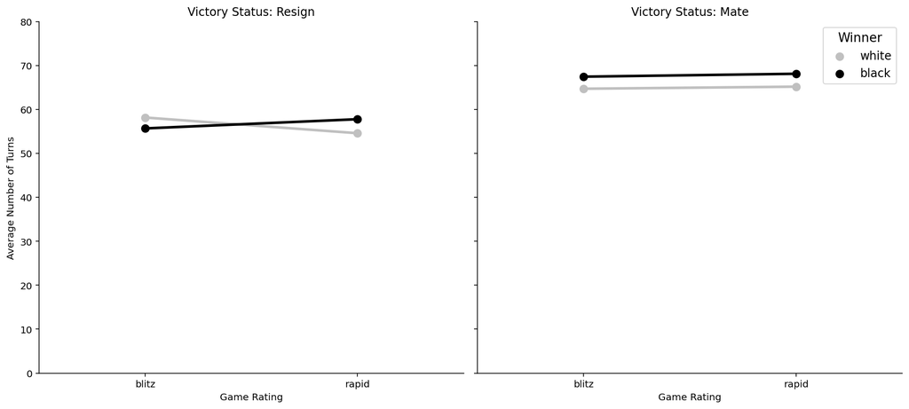

```python
# plotting game rating against number of turns for each winner  and each victory status

g = sb.FacetGrid(data=games, col='victory_status',col_order=['resign', 'mate'], height=6, aspect=1.1)
g.map(sb.pointplot,'game_rating' , 'turns', 'winner',order=['blitz','rapid'] , hue_order=['white','black']
      , palette=['silver', 'black'], ci=False);

g.axes[0,0].set_ylabel('Average Number of Turns');
g.axes[0,0].set_xlabel('Game Rating');
g.axes[0,1].set_xlabel('Game Rating');
g.axes[0,0].set_title('Victory Status: Resign');
g.axes[0,1].set_title('Victory Status: Mate');
plt.legend(title= 'Winner',title_fontsize=13, fontsize=12 );
plt.ylim(0,80);
```

Moving on to openings to see if there are certain openings that gurantee win for white or black.

I decided to look at the winner's rating instead of rating difference this time because I want to know what openings at each rating level that the players use to win.

```python
games[['white_rating','black_rating']].describe()
```

|  | white_rating | black_rating |
| --- | --- | --- |
| count | 13945.000000 | 13945.000000 |
| mean | 1596.955898 | 1592.431911 |
| std | 281.108813 | 286.383523 |
| min | 784.000000 | 789.000000 |
| 25% | 1397.000000 | 1390.000000 |
| 50% | 1576.000000 | 1569.000000 |
| 75% | 1791.000000 | 1787.000000 |
| max | 2622.000000 | 2571.000000 |

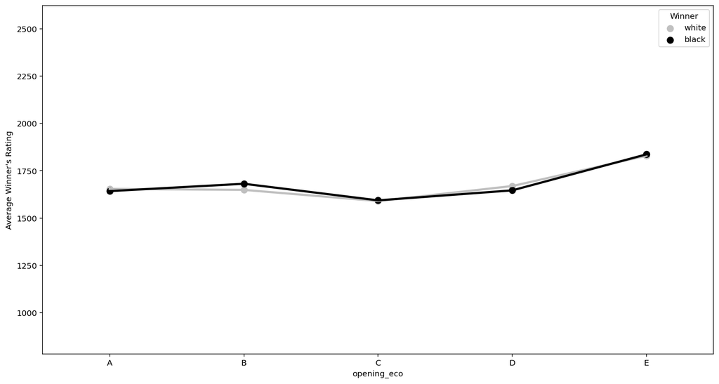

```python
# plotting the opening groups against the winner rating for white and black
plt.figure(figsize=(15,8))
white_data=games.query('winner=="white"').groupby('opening_eco')['white_rating'].mean()
sb.pointplot(x=white_data.index, y=white_data.values, hue=['white']*len(white_data.values),
                 palette=['silver']*len(white_data.values))

black_data=games.query('winner=="black"').groupby('opening_eco')['black_rating'].mean()
sb.pointplot(x=black_data.index, y=black_data.values, hue=['black']*len(black_data.values),
             palette=['black']*len(black_data.values))
plt.ylabel("Average Winner's Rating")
plt.legend(title='Winner');
plt.ylim(np.min([games['white_rating'].min(),games['black_rating'].min()]),
         np.max([games['white_rating'].max(),games['black_rating'].max()]));
```

It looks that openings of group E are used more by the highest rated players while the lowest rated player prefer openings of group C.

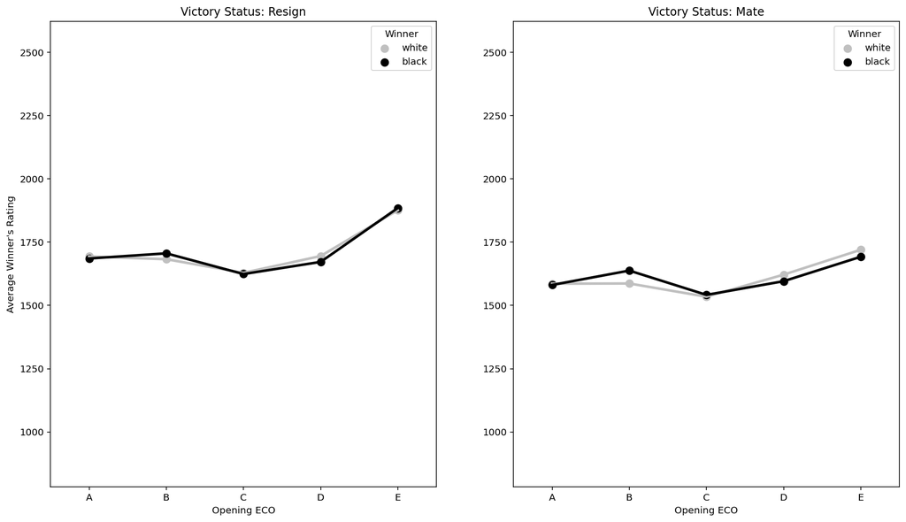

```python
# plotting the opening groups against the winner rating for white and black and for each victory status

plt.figure(figsize=(16,9))
plt.subplot(1,2,1)
white_data=games.query('winner=="white" & victory_status=="resign"').groupby('opening_eco')['white_rating'].mean().abs()
ax2=sb.pointplot(x=white_data.index, y=white_data.values, hue=['white']*len(white_data.values),
                 palette=['silver']*len(white_data.values))

black_data=games.query('winner=="black" & victory_status=="resign"').groupby('opening_eco')['black_rating'].mean().abs()
ax1= sb.pointplot(x=black_data.index, y=black_data.values, hue=['black']*len(black_data.values),
                  palette=['black']*len(black_data.values))
plt.xlabel('Opening ECO')
plt.ylabel("Average Winner's Rating")
plt.title('Victory Status: Resign');
plt.legend(title='Winner');
plt.ylim(np.min([games['white_rating'].min(),games['black_rating'].min()]),
         np.max([games['white_rating'].max(),games['black_rating'].max()]));


plt.subplot(1,2,2)
white_data=games.query('winner=="white" & victory_status=="mate"').groupby('opening_eco')['white_rating'].mean().abs()
ax2=sb.pointplot(x=white_data.index, y=white_data.values, hue=['white']*len(white_data.values),
                 palette=['silver']*len(white_data.values))

black_data=games.query('winner=="black" & victory_status=="mate"').groupby('opening_eco')['black_rating'].mean().abs()
ax1= sb.pointplot(x=black_data.index, y=black_data.values, hue=['black']*len(black_data.values),
                  palette=['black']*len(black_data.values))
plt.xlabel('Opening ECO')
plt.title('Victory Status: Mate');
plt.legend(title='Winner');
plt.ylim(np.min([games['white_rating'].min(),games['black_rating'].min()]),
         np.max([games['white_rating'].max(),games['black_rating'].max()]));
```

The same trends as earlier but with more highly rated players as black winning by chekmate using group B and E compared to other groups.

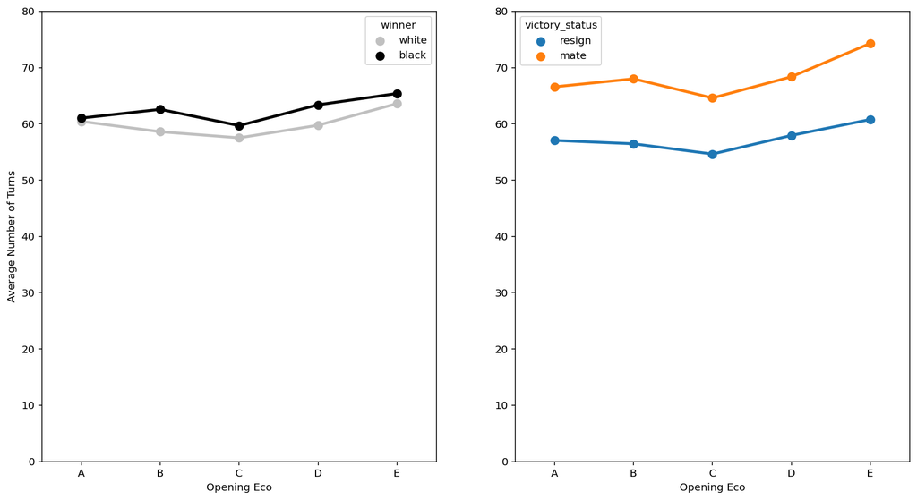

```python
# plotting the opening groups against the number of turns for each winner
plt.figure(figsize=(15,8))
plt.subplot(1,2,1)
sb.pointplot(data=games, x='opening_eco', y='turns', hue='winner', hue_order=['white','black'],
            palette=['silver', 'black'], ci=False)
plt.xlabel('Opening Eco')
plt.ylabel('Average Number of Turns');
plt.ylim(0,80);

# plotting the opening groups against the number of turns for each victory status
plt.subplot(1,2,2)
sb.pointplot(data=games, x='opening_eco', y='turns', hue='victory_status', hue_order=['resign','mate'],
            ci=False)
plt.xlabel('Opening Eco')
plt.ylabel('');
plt.ylim(0,80);
```

It takes black more number of turns, on average to win in each opening group and resigning from a game happens after less number of turns compared to checkmate in all opening groups.

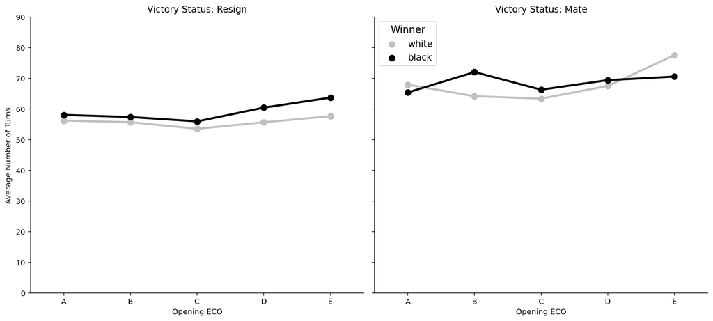

```python
# plotting the opening groups against the number of turns for each winner and for each victory status
g = sb.FacetGrid(data=games, col='victory_status',col_order=['resign', 'mate'], height=6, aspect=1.1)
g.map(sb.pointplot,'opening_eco' , 'turns', 'winner',order=['A','B','C','D','E'] , hue_order=['white','black']
      , palette=['silver', 'black'], ci=False);

g.axes[0,0].set_ylabel('Average Number of Turns');
g.axes[0,0].set_xlabel('Opening ECO');
g.axes[0,1].set_xlabel('Opening ECO');
g.axes[0,0].set_title('Victory Status: Resign');
g.axes[0,1].set_title('Victory Status: Mate');
plt.legend(title= 'Winner',title_fontsize=13, fontsize=12 );
plt.ylim(0,90);
```

Games which are won by resigning takes the highest number of turns at group E for black and white, however; the highst number of turns it takes to win by checkmate is at group B for black and at group E for white.

### Talk about some of the relationships you observed in this part of the investigation. Were there features that strengthened each other in terms of looking at your feature(s) of interest?

I investigated more the two factors, number of turns and players ratings, that showed the strongest variations with the winner and victory status and used them one by one with the other variables; game rating and opening groups. This multivariate investigation yielded some findings that were subtle before such as: